# 04_PINN_Solid_with_Data

**PINN with Data**

**Solid Mechanics Example**

By Prof. Seungchul Lee  
http://iai.postech.ac.kr/  
Industrial AI Lab at POSTECH

**Table of Contents**

# 1. Thin Plate (Solid Mechanics)

## 1.1. Problem Setup

- We will solve thin plate equations to find displacement and stress distribution of thin plate
- Based on *Kirchhoff-Love* plate theory, three hypotheses were used
  - straight lines normal to the mid-surface remain straight after deformation
  - straight lines normal to the mid-surface remain normal to the mid-surface after deformation
  - the thickness of the plate does not change during a deformation
- A non-uniform stretching force is applied to square elastic plate
- Only one quarter of the plate is considered since the geometry and in-plane forces are symmetric (yellow domain)

[figure not shown]

- Problem properties

$$ E = 50 \operatorname{Mpa}, \quad \nu = 0.3, \quad \omega = 20 \operatorname{mm}, \quad h = 1 \operatorname{mm}, \quad f = 1 \operatorname{Mpa} $$

- Governing equations (Föppl–von Kármán equations) for the isotropic elastic plate:

$$ \begin{align*} &{E \over 1 - \nu^2}\left({\partial^2 u \over \partial x^2} + {1 - \nu \over 2}{\partial^2 u \over \partial y^2} + {1 + \nu \over 2}{\partial^2 v \over \partial x \partial y} \right) = 0\\\\ &{E \over 1 - \nu^2}\left({\partial^2 v \over \partial y^2} + {1 - \nu \over 2}{\partial^2 v \over \partial x^2} + {1 + \nu \over 2}{\partial^2 x \over \partial x \partial y} \right) = 0 \end{align*} $$

- Two Dirichlet boundary conditions at $x = 0,\, y = 0\; (B.C.①, B.C.②)$:

$$ v(x,y) = 0 \qquad \text{at} \quad y = 0\\\\ u(x,y) = 0 \qquad \text{at} \quad x = 0 $$

- Two free boundary conditions at $y = \omega / 2\; (B.C.③)$:

$$ \sigma_{yy} = 0,\quad \sigma_{yx} = 0 $$

- Free boundary condition and in-plane force boundary condition at $x = \omega / 2\; (B.C.④)$:

$$ \sigma_{xx} = P \centerdot h,\quad \sigma_{xy} = 0 $$

- Make a neural network and loss funcitons like below:

[figure not shown]

## 1.2. Numerical Solution

- Numerical solution of this problem is illustrated in below figures
  - $x, y$ direction displacement and stress $u$, $v$, $\sigma_{xx}$, $\sigma_{yy}$, respectively
- Solve this problem using PINN and then compare with a numerical solution

[figure not shown]

```python
!pip install deepxde
```

```python
from deepxde.backend.set_default_backend import set_default_backend
set_default_backend("tensorflow")
```

```
Using backend: tensorflow
```

```
Setting the default backend to "tensorflow". You can change it in the ~/.deepxde/config.json file or export the DDEBACKEND environment variable. Valid options are: tensorflow.compat.v1, tensorflow, pytorch, jax, paddle (all lowercase)
```

## 1.3. PINN as PDE Solver

### 1.3.1. Define Parameters

```python
import deepxde as dde
import tensorflow as tf
import numpy as np
import random
import matplotlib.pyplot as plt
import math as m
```

```python
# Properties
E = 50
nu = 0.3
a = 10
b = 10
f = 1
h = 1
```

### 1.3.2. Define PDE with Boundary Conditions

```python
def boundary_x(X, on_boundary):
    return on_boundary and np.isclose(X[0], a)

def boundary_y(X, on_boundary):
    return on_boundary and np.isclose(X[1], b)

def boundary_y0(X, on_boundary):
    return on_boundary and np.isclose(X[1], 0)

def boundary_x0(X, on_boundary):
    return on_boundary and np.isclose(X[0], 0)
```

```python
def pde(X, Y):
    du_xx = dde.grad.hessian(Y, X, i = 0, j = 0, component = 0)
    du_yy = dde.grad.hessian(Y, X, i = 1, j = 1, component = 0)
    du_xy = dde.grad.hessian(Y, X, i = 0, j = 1, component = 0)
    dv_xx = dde.grad.hessian(Y, X, i = 0, j = 0, component = 1)
    dv_yy = dde.grad.hessian(Y, X, i = 1, j = 1, component = 1)
    dv_xy = dde.grad.hessian(Y, X, i = 0, j = 1, component = 1)

    force_eq_x = (du_xx + 0.5 * (1 - nu) * du_yy + 0.5 * (1 + nu) * dv_xy) * E / (1 - nu**2)
    force_eq_y = (dv_yy + 0.5 * (1 - nu) * dv_xx + 0.5 * (1 + nu) * du_xy) * E / (1 - nu**2)

    return [force_eq_x, force_eq_y]
```

```python
def BC_xy(X, Y):
    du_x = dde.grad.jacobian(Y, X, i = 0, j = 0)
    du_y = dde.grad.jacobian(Y, X, i = 0, j = 1)
    dv_x = dde.grad.jacobian(Y, X, i = 1, j = 0)
    dv_y = dde.grad.jacobian(Y, X, i = 1, j = 1)

    sig_xx = (du_x + nu * dv_y) * E / (1 - nu**2)
    sig_yy = (dv_y + nu * du_x) * E / (1 - nu**2)
    sig_xy = (dv_x + du_y) * E / (1 + nu) / 2

    sig_ex = f * h * tf.reshape(tf.math.cos(np.pi / (2 * b) * X[:,1]), [-1, 1])

    return sig_xx-sig_ex, sig_xy, sig_yy
```

### 1.3.3. Define Geometry and Implement Boundary Condition

```python
geom = dde.geometry.Rectangle(xmin = [0, 0], xmax = [a, b])

bc_Y0 = dde.DirichletBC(geom, lambda x:0, boundary_y0, component = 1)
bc_X0 = dde.DirichletBC(geom, lambda x:0, boundary_x0, component = 0)

bc_free_yy = dde.OperatorBC(geom, lambda x, y, _ : BC_xy(x,y)[2], boundary_y)
bc_free_yx = dde.OperatorBC(geom, lambda x, y, _ : BC_xy(x,y)[1], boundary_y)

bc_traction = dde.OperatorBC(geom, lambda x, y, _ : BC_xy(x,y)[0], boundary_x)
bc_free_xy = dde.OperatorBC(geom, lambda x, y, _ : BC_xy(x,y)[1], boundary_x)
```

```python
data = dde.data.PDE(geom,
                    pde,
                    [bc_traction, bc_free_xy, bc_free_yx, bc_free_yy, bc_Y0, bc_X0],
                    num_domain = 9000,
                    num_boundary = 1000,
                    num_test = 100)
```

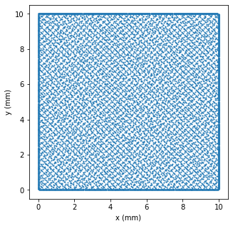

```python
plt.figure(figsize = (5,5))
plt.scatter(data.train_x[:,0], data.train_x[:,1], s = 1)
plt.xlabel('x (mm)')
plt.ylabel('y (mm)')
plt.show()
```

### 1.3.4. Define Network and Hyper-parameters

```python
layer_size = [2] + [64] * 5 + [2]
activation = "tanh"
initializer = "Glorot uniform"

net = dde.nn.tensorflow.fnn.FNN(layer_size, activation, initializer)

model = dde.Model(data, net)
model.compile("adam", lr = 1e-3)
```

```
Compiling model...
'compile' took 0.000484 s
```

### 1.3.5. Train (Adam Optimizer)

[output not shown]

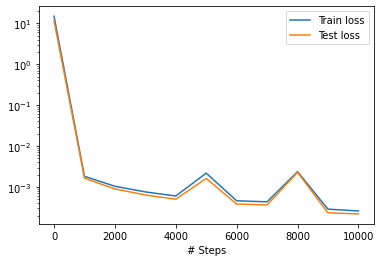

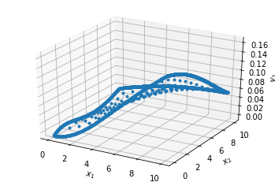

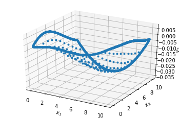

```python
losshistory, train_state = model.train(epochs = 10000)
dde.saveplot(losshistory, train_state, issave = False, isplot = True)
```

### 1.3.6. Plot Displacement (Adam Optimzer)

```python
color_legend = [[0, 0.182], [-0.06, 0.011], [-0.0022,1.0], [-0.15, 0.45]]
title = ['x-displacement ($u$)', 'y-displacement ($v$)', '$\sigma_{xx}$', '$\sigma_{yy}$']
```

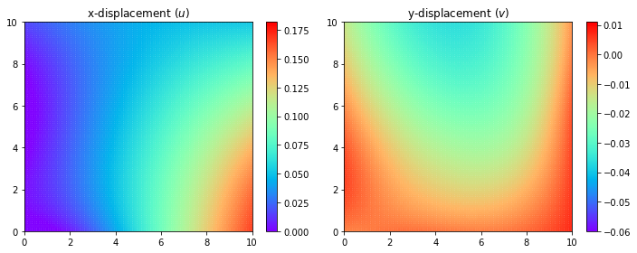

```python
samples = geom.uniform_points(10201)
pde_disp = model.predict(samples)

plt.figure(figsize = (10, 4))
for idx in range(2):
    plt.subplot(1,2,idx+1)
    plt.scatter(samples[:, 0],
                samples[:, 1],
                c = pde_disp[:, idx],
                cmap = 'rainbow',
                s = 5)
    plt.clim(color_legend[idx])
    plt.title(title[idx])
    plt.xlim((0, a))
    plt.ylim((0, b))
    plt.colorbar()
plt.tight_layout()
plt.show()
```

### 1.3.7. Train More (L-BFGS Optimizer)

```
Compiling model...
'compile' took 0.061669 s

Training model...

Step      Train loss                                                                          Test loss                                                                           Test metric
10000     [2.86e-05, 7.52e-05, 2.42e-05, 1.14e-05, 1.95e-05, 7.09e-05, 4.71e-06, 2.64e-05]    [1.91e-05, 4.48e-05, 2.42e-05, 1.14e-05, 1.95e-05, 7.09e-05, 4.71e-06, 2.64e-05]    []
11845     [2.01e-06, 1.90e-06, 4.77e-07, 3.82e-07, 2.05e-07, 5.41e-07, 5.52e-07, 6.17e-07]    [1.61e-06, 1.53e-06, 4.77e-07, 3.82e-07, 2.05e-07, 5.41e-07, 5.52e-07, 6.17e-07]    []

Best model at step 11845:
  train loss: 6.69e-06
  test loss: 5.91e-06
  test metric: []

'train' took 487.722181 s
```

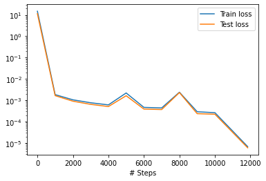

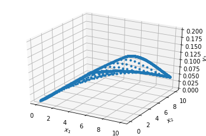

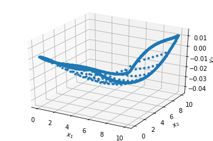

```python
dde.optimizers.config.set_LBFGS_options(maxiter = 3000)
model.compile("L-BFGS")
losshistory, train_state = model.train()
dde.saveplot(losshistory, train_state, issave = False, isplot = True)
```

### 1.3.8. Plot Displacement (Adam + L-BFGS)

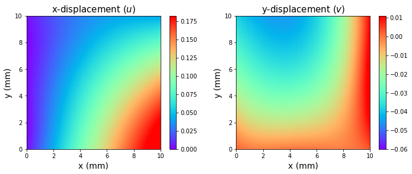

```python
pde_disp = model.predict(samples)

plt.figure(figsize = (10, 4))
for idx in range(2):
    plt.subplot(1,2,idx+1)
    plt.scatter(samples[:, 0],
                samples[:, 1],
                c = pde_disp[:, idx],
                cmap = 'rainbow',
                s = 5)
    plt.clim(color_legend[idx])
    plt.title(title[idx], fontsize = 15)
    plt.xlabel('x (mm)', fontsize = 14)
    plt.ylabel('y (mm)', fontsize = 14)
    plt.axis('square')
    plt.xlim((0, a))
    plt.ylim((0, b))
    plt.colorbar()
plt.tight_layout()
plt.show()
```

### 1.3.9 Plot Stress

- Since the neural network's output is only x and y displacement, we should autograd to calculate stress
  - If we assume that the Cauchy stress tensor components are linearly related to the von Kármán strains by Hooke's law, stress can be represented as:

$$ \sigma_{xx} = {E \over 1 - \nu^2}\left({\partial u \over \partial x} + \nu {\partial v \over \partial y} \right)\\\\ \sigma_{yy} = {E \over 1 - \nu^2}\left({\partial v \over \partial y} + \nu {\partial u \over \partial x} \right) $$

```python
def check_stress(net, X):
    X = tf.constant(X)

    with tf.GradientTape(persistent=True) as tape:
      tape.watch(X)
      disp = net(X)
      u_pred = tf.reshape(disp[:,0],[-1,1])
      v_pred = tf.reshape(disp[:,1],[-1,1])

    du_xy = tape.gradient(u_pred, X)
    dv_xy = tape.gradient(v_pred, X)

    du_x, du_y = du_xy[:,0], du_xy[:,1]
    dv_x, dv_y = dv_xy[:,0], dv_xy[:,1]

    sig_xx = tf.reshape(((du_x + nu * dv_y) * E / (1 - nu**2)), [-1, 1])
    sig_yy = tf.reshape(((dv_y + nu * du_x) * E / (1 - nu**2)), [-1, 1])

    return sig_xx, sig_yy
```

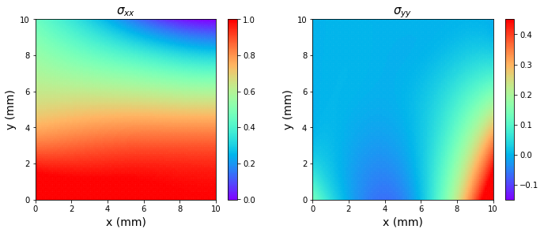

```python
sig_x, sig_y = check_stress(model.net, samples)
pde_sig = np.hstack([sig_x, sig_y])

plt.figure(figsize = (10, 4))
for idx in range(2):
    plt.subplot(1,2,idx + 1)
    plt.scatter(samples[:, 0],
                samples[:, 1],
                c = pde_sig[:, idx],
                cmap = 'rainbow',
                s = 5)
    plt.clim(color_legend[idx + 2])
    plt.title(title[idx + 2], fontsize = 15)
    plt.xlabel('x (mm)', fontsize = 14)
    plt.ylabel('y (mm)', fontsize = 14)
    plt.axis('square')
    plt.xlim((0, a))
    plt.ylim((0, b))
    plt.colorbar()
plt.tight_layout()
plt.show()
```

# 2. Data-driven Approach with Big data

## 2.1. Load and Sample Data

[Data Download](https://www.dropbox.com/scl/fi/m7cl51vxbu00dq5qghlmh/Plate_data.npy?rlkey=8hlnk7ow3zys5tpr7m8xeiakv&dl=1)

```python
from google.colab import drive
drive.mount('/content/drive/')
```

```python
Plate_data = np.load('/content/drive/MyDrive/postech/KSNVE/data_files/Plate_data.npy')
loc = Plate_data[:, 0:2]
u = Plate_data[:, 2:3]
v = Plate_data[:, 3:4]
stress = Plate_data[:, 4:6]
```

```python
tr_sample = np.array([np.where(loc[:,0] == i) for i in range(11)]).reshape(-1,)
x_sample = loc[tr_sample,:]
u_sample = u[tr_sample,:]
v_sample = v[tr_sample,:]
```

```python
observe_u = dde.icbc.PointSetBC(x_sample, u_sample, component = 0)
observe_v = dde.icbc.PointSetBC(x_sample, v_sample, component = 1)
```

## 2.2. Define Geometry

```python
geom = dde.geometry.Rectangle(xmin = [0, 0], xmax = [a, b])
data = dde.data.PDE(geom,
                    None,
                    [observe_u, observe_v],
                    num_domain = 0,
                    num_boundary = 0,
                    num_test = 100)
```

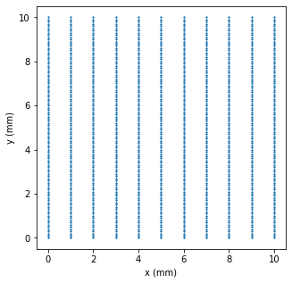

```python
plt.figure(figsize = (5,5))
plt.scatter(data.train_x[:,0], data.train_x[:,1], s = 1)
plt.xlim([-0.5,10.5])
plt.xlabel('x (mm)')
plt.ylabel('y (mm)')
plt.show()
```

## 2.3. Define Network and Hyper-parameters

```python
layer_size = [2] + [64] * 5 + [2]
activation = "tanh"
initializer = "Glorot uniform"

net = dde.maps.FNN(layer_size, activation, initializer)

model = dde.Model(data, net)
model.compile("adam", lr = 1e-3)
```

```
Compiling model...
'compile' took 0.000571 s
```

## 2.4. Train (Adam Optimizer)

```python
losshistory, train_state = model.train(epochs = 10000)
dde.saveplot(losshistory, train_state, issave = False, isplot = False)
```

```
Training model...

Step      Train loss              Test loss               Test metric
0         [1.59e-01, 2.42e-02]    [1.59e-01, 2.42e-02]    []
1000      [4.53e-06, 8.47e-06]    [4.53e-06, 8.47e-06]    []
2000      [1.38e-06, 2.61e-06]    [1.38e-06, 2.61e-06]    []
3000      [1.17e-06, 2.61e-06]    [1.17e-06, 2.61e-06]    []
4000      [1.39e-06, 1.91e-06]    [1.39e-06, 1.91e-06]    []
5000      [6.86e-07, 9.91e-07]    [6.86e-07, 9.91e-07]    []
6000      [5.49e-07, 6.23e-07]    [5.49e-07, 6.23e-07]    []
7000      [1.29e-06, 1.57e-06]    [1.29e-06, 1.57e-06]    []
8000      [2.54e-07, 3.74e-07]    [2.54e-07, 3.74e-07]    []
9000      [2.44e-07, 4.57e-07]    [2.44e-07, 4.57e-07]    []
10000     [1.65e-07, 3.83e-07]    [1.65e-07, 3.83e-07]    []

Best model at step 10000:
  train loss: 5.47e-07
  test loss: 5.47e-07
  test metric: []

'train' took 13.647047 s
```

## 2.5. Train More (L-BFGS Optimizer)

```
Compiling model...
'compile' took 0.013668 s

Training model...

Step      Train loss              Test loss               Test metric
10000     [1.65e-07, 3.83e-07]    [1.65e-07, 3.83e-07]    []
11241     [2.99e-09, 3.91e-09]    [2.99e-09, 3.91e-09]    []

Best model at step 11241:
  train loss: 6.90e-09
  test loss: 6.90e-09
  test metric: []

'train' took 251.334709 s
```

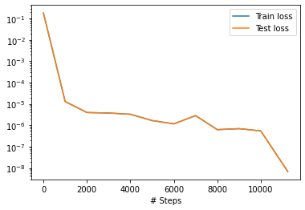

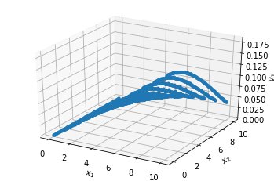

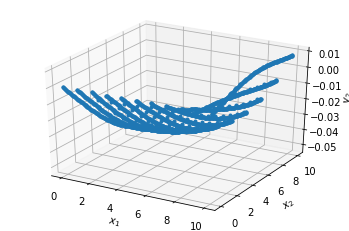

```python
dde.optimizers.config.set_LBFGS_options(maxiter = 5000)
model.compile("L-BFGS")
losshistory, train_state = model.train()
dde.saveplot(losshistory, train_state, issave = False, isplot = True)
```

## 2.6. Plot Results (Adam + L-BFGS)

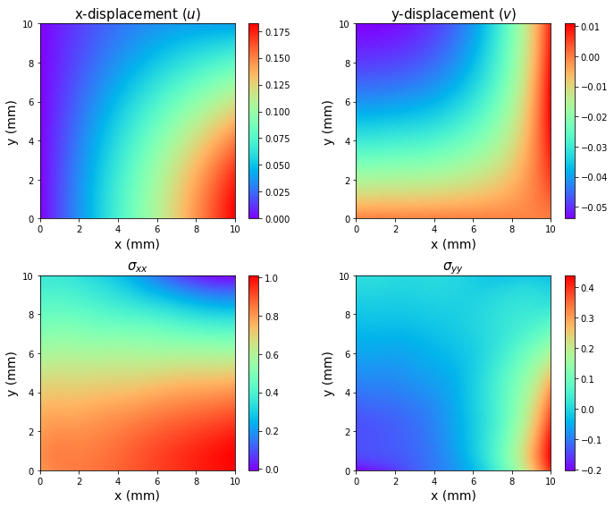

```python
big_disp = model.predict(samples)
sig_x, sig_y = np.array(check_stress(model.net, samples))
big_sig = np.hstack([sig_x, sig_y])
big_result = np.hstack([big_disp, big_sig])

plt.figure(figsize = (10, 8))
for idx in range(4):
    plt.subplot(2,2,idx + 1)
    plt.scatter(samples[:, 0],
                samples[:, 1],
                c = big_result[:,idx],
                cmap = 'rainbow',
                s = 5)
    plt.title(title[idx], fontsize = 15)
    plt.xlabel('x (mm)', fontsize = 14)
    plt.ylabel('y (mm)', fontsize = 14)
    plt.axis('square')
    plt.xlim((0, a))
    plt.ylim((0, b))
    plt.colorbar()
plt.tight_layout()
plt.show()
```

# 3. Data-driven Approach with Small Data

## 3.1. Sample Data

```python
tr_sample = np.array([np.where(loc[:,0] == i) for i in [2,5,8]]).reshape(-1,)
x_sample = loc[tr_sample,:]
u_sample = u[tr_sample,:]
v_sample = v[tr_sample,:]
```

```python
observe_u = dde.icbc.PointSetBC(x_sample, u_sample, component = 0)
observe_v = dde.icbc.PointSetBC(x_sample, v_sample, component = 1)
```

## 3.2. Define Geometry

```python
geom = dde.geometry.Rectangle(xmin = [0, 0], xmax = [a, b])
data = dde.data.PDE(geom,
                    None,
                    [observe_u, observe_v],
                    num_domain = 0,
                    num_boundary = 0,
                    num_test = 100)
```

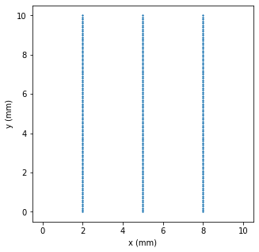

```python
plt.figure(figsize = (5,5))
plt.scatter(data.train_x[:,0], data.train_x[:,1], s = 1)
plt.xlim([-0.5,10.5])
plt.xlabel('x (mm)')
plt.ylabel('y (mm)')
plt.show()
```

## 3.3. Define Network and Hyper-parameters

```python
layer_size = [2] + [64] * 5 + [2]
activation = "tanh"
initializer = "Glorot uniform"

net = dde.maps.FNN(layer_size, activation, initializer)

model = dde.Model(data, net)
model.compile("adam", lr = 1e-3)
```

```
Compiling model...
'compile' took 0.000519 s
```

## 3.4. Train (Adam Optimizer)

```python
losshistory, train_state = model.train(epochs = 10000)
dde.saveplot(losshistory, train_state, issave = False, isplot = False)
```

```
Training model...

Step      Train loss              Test loss               Test metric
0         [2.97e-01, 1.21e-01]    [2.97e-01, 1.21e-01]    []
1000      [1.08e-06, 1.86e-06]    [1.08e-06, 1.86e-06]    []
2000      [4.63e-07, 3.86e-07]    [4.63e-07, 3.86e-07]    []
3000      [4.39e-07, 2.20e-07]    [4.39e-07, 2.20e-07]    []
4000      [1.72e-07, 1.09e-07]    [1.72e-07, 1.09e-07]    []
5000      [1.82e-07, 1.18e-07]    [1.82e-07, 1.18e-07]    []
6000      [4.51e-08, 3.86e-08]    [4.51e-08, 3.86e-08]    []
7000      [6.11e-08, 3.05e-08]    [6.11e-08, 3.05e-08]    []
8000      [3.36e-08, 1.38e-08]    [3.36e-08, 1.38e-08]    []
9000      [1.74e-08, 9.04e-09]    [1.74e-08, 9.04e-09]    []
10000     [2.42e-06, 6.06e-07]    [2.42e-06, 6.06e-07]    []

Best model at step 9000:
  train loss: 2.64e-08
  test loss: 2.64e-08
  test metric: []

'train' took 14.176561 s
```

## 3.5. Train More (L-BFGS Optimizer)

```
Compiling model...
'compile' took 0.015152 s

Training model...

Step      Train loss              Test loss               Test metric
10000     [2.42e-06, 6.06e-07]    [2.42e-06, 6.06e-07]    []
10233     [3.53e-09, 2.98e-09]    [3.53e-09, 2.98e-09]    []

Best model at step 10233:
  train loss: 6.51e-09
  test loss: 6.51e-09
  test metric: []

'train' took 49.376678 s
```

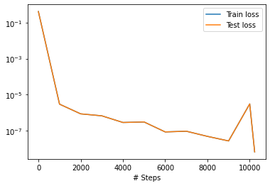

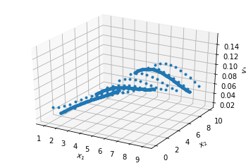

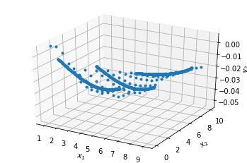

```python
dde.optimizers.config.set_LBFGS_options(maxiter = 5000)
model.compile("L-BFGS")
losshistory, train_state = model.train()
dde.saveplot(losshistory, train_state, issave = False, isplot = True)
```

## 3.6. Plot Results (Adam + L-BFGS)

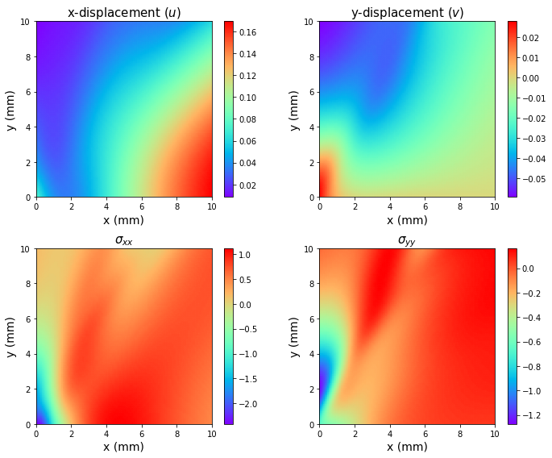

```python
small_disp = model.predict(samples)
sig_x, sig_y = np.array(check_stress(model.net, samples))
small_sig = np.hstack([sig_x, sig_y])
small_result = np.hstack([small_disp, small_sig])

plt.figure(figsize = (10, 8))
for idx in range(4):
    plt.subplot(2,2,idx + 1)
    plt.scatter(samples[:, 0],
                samples[:, 1],
                c = small_result[:,idx],
                cmap = 'rainbow',
                s = 5)
    plt.title(title[idx], fontsize = 15)
    plt.xlabel('x (mm)', fontsize = 14)
    plt.ylabel('y (mm)', fontsize = 14)
    plt.axis('square')
    plt.xlim((0, a))
    plt.ylim((0, b))
    plt.colorbar()
plt.tight_layout()
plt.show()
```

# 4. PINN with Small Data

```python
data = dde.data.PDE(geom,
                    pde,
                    [bc_traction, bc_free_xy, bc_free_yx, bc_free_yy, bc_Y0, bc_X0, observe_u, observe_v],
                    num_domain = 100,
                    num_boundary = 100,
                    num_test = 100,
                    train_distribution = 'LHS')
```

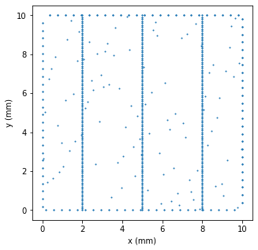

```python
plt.figure(figsize = (5,5))
plt.scatter(data.train_x[:,0], data.train_x[:,1], s = 1)
plt.xlabel('x (mm)')
plt.ylabel('y (mm)')
plt.show()
```

## 4.1. Define Network and Hyper-parameters

```python
layer_size = [2] + [64] * 5 + [2]
activation = "tanh"
initializer = "Glorot uniform"

net = dde.maps.FNN(layer_size, activation, initializer)

model = dde.Model(data, net)
model.compile("adam", lr = 1e-3, loss_weights=[1, 1, 1, 1, 1, 1, 1, 1, 9, 9])
```

```
Compiling model...
'compile' took 0.000449 s
```

## 4.2 Train (Adam Optimizer)

```python
losshistory, train_state = model.train(epochs = 10000)
dde.saveplot(losshistory, train_state, issave = False, isplot = False)
```

```
Training model...

Step      Train loss                                                                                              Test loss                                                                                               Test metric
0         [1.17e+00, 7.98e-01, 7.78e-01, 2.30e+00, 5.54e-01, 1.29e+00, 3.63e-03, 2.34e-01, 1.67e+00, 1.54e-02]    [3.42e-01, 4.91e-01, 7.78e-01, 2.30e+00, 5.54e-01, 1.29e+00, 3.63e-03, 2.34e-01, 1.67e+00, 1.54e-02]    []
1000      [5.96e-04, 6.56e-04, 2.22e-04, 9.00e-05, 3.54e-05, 5.39e-05, 8.53e-05, 2.34e-05, 2.69e-04, 1.84e-04]    [5.34e-04, 9.55e-04, 2.22e-04, 9.00e-05, 3.54e-05, 5.39e-05, 8.53e-05, 2.34e-05, 2.69e-04, 1.84e-04]    []
2000      [2.33e-04, 3.09e-04, 8.81e-05, 5.92e-05, 1.81e-05, 3.28e-05, 2.33e-05, 4.71e-06, 9.17e-05, 2.34e-05]    [2.92e-04, 3.76e-04, 8.81e-05, 5.92e-05, 1.81e-05, 3.28e-05, 2.33e-05, 4.71e-06, 9.17e-05, 2.34e-05]    []
3000      [2.28e-04, 2.19e-04, 8.99e-05, 6.13e-05, 3.80e-05, 6.85e-05, 1.68e-05, 2.65e-05, 3.21e-04, 7.05e-05]    [1.50e-04, 2.35e-04, 8.99e-05, 6.13e-05, 3.80e-05, 6.85e-05, 1.68e-05, 2.65e-05, 3.21e-04, 7.05e-05]    []
4000      [7.01e-05, 1.39e-04, 2.64e-05, 3.11e-05, 9.59e-06, 2.32e-05, 7.36e-06, 3.76e-06, 3.49e-05, 5.87e-06]    [9.17e-05, 1.61e-04, 2.64e-05, 3.11e-05, 9.59e-06, 2.32e-05, 7.36e-06, 3.76e-06, 3.49e-05, 5.87e-06]    []
5000      [4.29e-05, 1.14e-04, 1.44e-05, 2.27e-05, 1.01e-05, 1.92e-05, 5.99e-06, 3.39e-06, 2.43e-05, 4.89e-06]    [5.17e-05, 1.09e-04, 1.44e-05, 2.27e-05, 1.01e-05, 1.92e-05, 5.99e-06, 3.39e-06, 2.43e-05, 4.89e-06]    []
6000      [2.06e-05, 5.84e-05, 5.11e-06, 1.19e-05, 7.06e-06, 9.13e-06, 3.05e-06, 2.59e-06, 1.32e-05, 2.87e-06]    [3.66e-05, 6.16e-05, 5.11e-06, 1.19e-05, 7.06e-06, 9.13e-06, 3.05e-06, 2.59e-06, 1.32e-05, 2.87e-06]    []
7000      [1.87e-04, 8.14e-05, 9.08e-04, 1.76e-05, 9.15e-06, 2.63e-04, 6.00e-06, 8.46e-05, 8.47e-04, 1.05e-05]    [2.31e-04, 6.14e-05, 9.08e-04, 1.76e-05, 9.15e-06, 2.63e-04, 6.00e-06, 8.46e-05, 8.47e-04, 1.05e-05]    []
8000      [1.82e-05, 1.81e-04, 3.04e-04, 3.88e-05, 5.11e-05, 2.34e-05, 6.37e-05, 7.70e-06, 9.62e-05, 1.07e-03]    [3.23e-05, 1.68e-04, 3.04e-04, 3.88e-05, 5.11e-05, 2.34e-05, 6.37e-05, 7.70e-06, 9.62e-05, 1.07e-03]    []
9000      [1.50e-05, 2.37e-05, 1.79e-06, 6.13e-06, 5.14e-06, 3.55e-06, 1.37e-06, 1.36e-06, 6.87e-06, 1.75e-06]    [2.30e-05, 2.59e-05, 1.79e-06, 6.13e-06, 5.14e-06, 3.55e-06, 1.37e-06, 1.36e-06, 6.87e-06, 1.75e-06]    []
10000     [4.81e-05, 7.37e-05, 2.26e-04, 4.43e-05, 3.52e-05, 7.69e-05, 2.92e-05, 1.06e-05, 1.05e-04, 3.56e-04]    [7.22e-05, 5.39e-05, 2.26e-04, 4.43e-05, 3.52e-05, 7.69e-05, 2.92e-05, 1.06e-05, 1.05e-04, 3.56e-04]    []

Best model at step 9000:
  train loss: 6.66e-05
  test loss: 7.69e-05
  test metric: []

'train' took 35.974494 s
```

## 4.3. Train More (L-BFGS Optimizer)

```
Compiling model...
'compile' took 0.063803 s

Training model...

Step      Train loss                                                                                              Test loss                                                                                               Test metric
10000     [4.81e-05, 7.37e-05, 2.26e-04, 4.43e-05, 3.52e-05, 7.69e-05, 2.92e-05, 1.06e-05, 1.17e-05, 3.96e-05]    [7.22e-05, 5.39e-05, 2.26e-04, 4.43e-05, 3.52e-05, 7.69e-05, 2.92e-05, 1.06e-05, 1.17e-05, 3.96e-05]    []
11310     [2.03e-06, 1.42e-06, 2.60e-07, 1.83e-07, 1.07e-07, 4.87e-07, 5.01e-08, 8.72e-08, 1.45e-07, 9.32e-08]    [4.18e-06, 1.98e-06, 2.60e-07, 1.83e-07, 1.07e-07, 4.87e-07, 5.01e-08, 8.72e-08, 1.45e-07, 9.32e-08]    []

Best model at step 11310:
  train loss: 4.86e-06
  test loss: 7.57e-06
  test metric: []

'train' took 281.476495 s
```

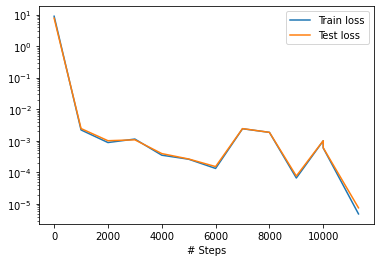

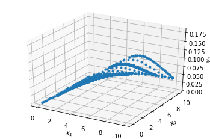

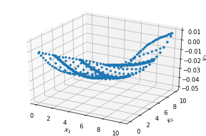

```python
dde.optimizers.config.set_LBFGS_options(maxiter = 5000)
model.compile("L-BFGS")
losshistory, train_state = model.train()
dde.saveplot(losshistory, train_state, issave = False, isplot = True)
```

## 4.4. Plot Results (Adam + L-BFGS)

[output not shown]

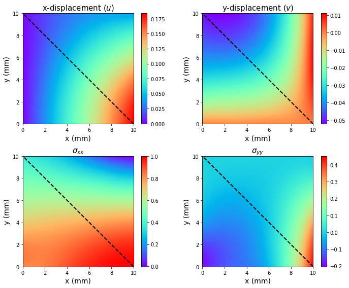

```python
pde_small_disp = model.predict(samples)
sig_x, sig_y = np.array(check_stress(model.net, samples))
pde_small_sig = np.hstack([sig_x, sig_y])
pde_small_result = np.hstack([pde_small_disp, pde_small_sig])

diag_x = np.arange(100, -1, -1)/10

plt.figure(figsize = (10, 8))
for idx in range(4):
    plt.subplot(2,2,idx+1)
    plt.scatter(samples[:, 0],
                samples[:, 1],
                c = pde_small_result[:,idx],
                cmap = 'rainbow',
                s = 5)
    plt.plot(diag_x, diag_x[::-1], '--', c = 'k', linewidth = 2)
    plt.title(title[idx], fontsize = 15)
    plt.xlabel('x (mm)', fontsize = 14)
    plt.ylabel('y (mm)', fontsize = 14)
    plt.axis('square')
    plt.xlim((0, a))
    plt.ylim((0, b))
    plt.colorbar()
plt.tight_layout()
plt.show()
```

## 4.5. Plot with All Results

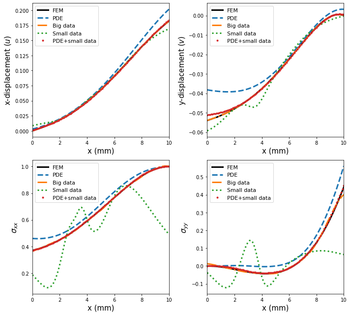

```python
diag_ = [i for i in range(u.shape[0]) if loc[i,0] + loc[i,1] == 10]

diag_result_true = [u[diag_], v[diag_], stress[diag_, 0], stress[diag_, 1]]
diag_result_pde = [pde_disp[diag_, 0], pde_disp[diag_, 1], pde_sig[diag_, 0], pde_sig[diag_, 1]]
diag_result_big = [big_disp[diag_, 0], big_disp[diag_, 1], big_sig[diag_, 0], big_sig[diag_, 1]]
diag_result_small = [small_disp[diag_, 0], small_disp[diag_, 1], small_sig[diag_, 0], small_sig[diag_, 1]]
diag_result_pde_small = [pde_small_disp[diag_, 0], pde_small_disp[diag_, 1], pde_small_sig[diag_, 0], pde_small_sig[diag_, 1]]

plt.figure(figsize = (10, 9))
for idx in range(4):
    plt.subplot(2,2,idx+1)
    plt.plot(loc[diag_,0], diag_result_true[idx], 'k' , linewidth = 3, label = 'FEM')
    plt.plot(loc[diag_,0], diag_result_pde[idx], '--' , linewidth = 3, label = 'PDE')
    plt.plot(loc[diag_,0], diag_result_big[idx], '-.', linewidth = 3, label = 'Big data')
    plt.plot(loc[diag_,0], diag_result_small[idx], ':', linewidth = 3, label = 'Small data')
    plt.plot(loc[diag_,0], diag_result_pde_small[idx], '.', linewidth = 3, label = 'PDE+small data')
    plt.xlabel('x (mm)', fontsize = 15)
    plt.ylabel(title[idx], fontsize = 15)
    plt.xlim((0, a))
    plt.legend(fontsize = 11)
plt.tight_layout()
plt.show()
```

```python
%%javascript
$.getScript('https://kmahelona.github.io/ipython_notebook_goodies/ipython_notebook_toc.js')
```